# Statistical inference with the GSS data

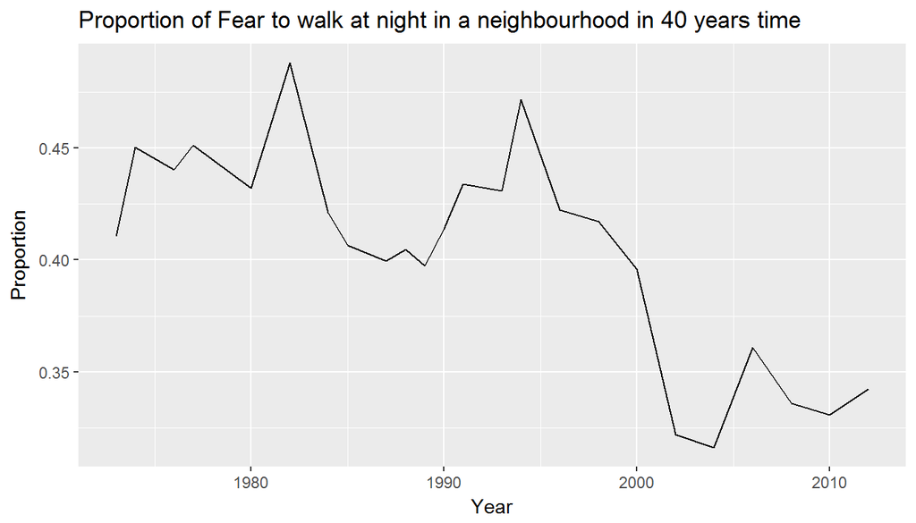

```r
# making the plot of fear
gss %>%
      select(year,fear) %>%
      na.omit() %>%
      group_by(year) %>%
      mutate(feard = ifelse(fear == "Yes", 1,0)) %>%
      summarise(propF = mean(feard)) %>%
      ggplot(aes(year, propF)) +
      geom_line() +
      labs(x = "Year",y = "Proportion",title = "Proportion of Fear to walk at night in a neighbourhood in 40 years time")
```

What we see here is a significant decline of the gun ownership in total of the 40 years of this observational study. We can also see the increase in gun ownership after year 2000, which is a historical moment I’ve mentioned in the beginning of this analyses. One other thing that cought my attention is the lowest percentage of gun ownership in year 2010. And what about fear? Fear found its peak after 1980, in about 1982,1983 at a level of a bit less than 50% = meaning that nearly half of the respondents from the study were afraid to walk at night during 1982/1983 year. We observe a decline in 2004 of a bit less than 32.5% of the people wer afraid.

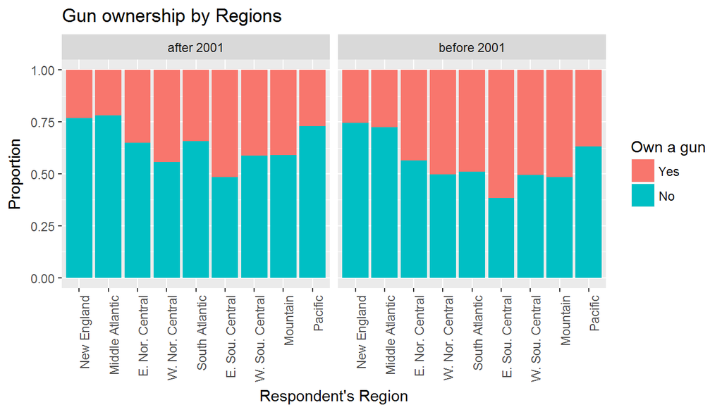

```r
# I would like to make a plot displaying gun ownership in every region segmented by the year before and after 2001
ggplot(dff, aes(x = region,fill = owngun)) +
      geom_bar(position = "fill") +
      labs(x = "Respondent's Region",y = "Proportion",title = "Gun ownership by Regions") +
      scale_fill_discrete(name = "Own a gun") +
      facet_grid(~dev2001) +
      theme(axis.text.x = element_text(angle = 90, hjust = 1))
```

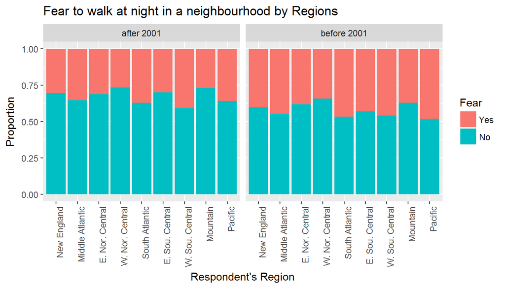

```r
# I would like to make a plot displaying fear to walk in a neighbourhood in every region segmented by the year before and after 2001
ggplot(dff, aes(x = region,fill=fear)) +
      geom_bar(position = "fill") +
      labs(x = "Respondent's Region",y = "Proportion",title = "Fear to walk at night in a neighbourhood by Regions") +
      scale_fill_discrete(name = "Fear") +
      facet_grid(~dev2001) +
      theme(axis.text.x = element_text(angle = 90, hjust = 1))
```

## Part 4: Inference

In this section I will perform statistical inference. And try to answer the research question from section 2 -mIs there a relationship between gun ownership and a respondent’s region of residence?

```
  1. Define hypothesis
  2. Choose statistical method
  3. Check for conditions
  4. Perform the inference tests
  5. Interpret the results
```

**1. Define hypothesis**

The **null hypothesis** (H0): the region of the respondent independent to a positive answer of the question whether the respondent owns a gun. The **alternative hypothesis** (HA):the region of the respondent dependent to a positive answer of the question whether the respondent owns a gun.

**2. Choose statistical method**

In order to answer the research question /Is there a relationship between gun ownership and a respondent’s region of residence?/ I will use chi-square test of independence. We use this test when comparing 2 categorical variables where one of the variables has more than 2 levels.

**3. Check for conditions**

The key conditions for the chi square test of independence are: Independence between observations. This is assumed to be true based on the sampling methodology used in the GSS, as it uses random sampling. Furthermore, the size of the sample is less than 10% of the population, and each result is only counted in one cell.  
Sample size.

```r
sum(df_table <= 10)
```

```
## [1] 0
```

We have at least 10 counts for each cell.

**4. Perform the inference tests**

Now we perform the inference calculation using the chi-square test.

```r
# perform the chi-square test.
chisq.test(df_table)
```

```
##
##  Pearson's Chi-squared test
##
## data:  df_table
## X-squared = 1229.9, df = 8, p-value < 2.2e-16
```

**5. Interpret the results**  
Since the p-value is below alpha (0.05), we can conclude that there is sufficient evidence to reject H0 (null hypothesis). In context of the research question, this means, that region is related to gun ownership. But I can’t make a causal statment since this is an observational data.